# nuspectral demo

Let us test **nuspectral** with synthetic colored noise with Milankovitch frequencies. To generate it, we use the method of [Kirchner (2005)](https://journals.aps.org/pre/abstract/10.1103/PhysRevE.71.066110).

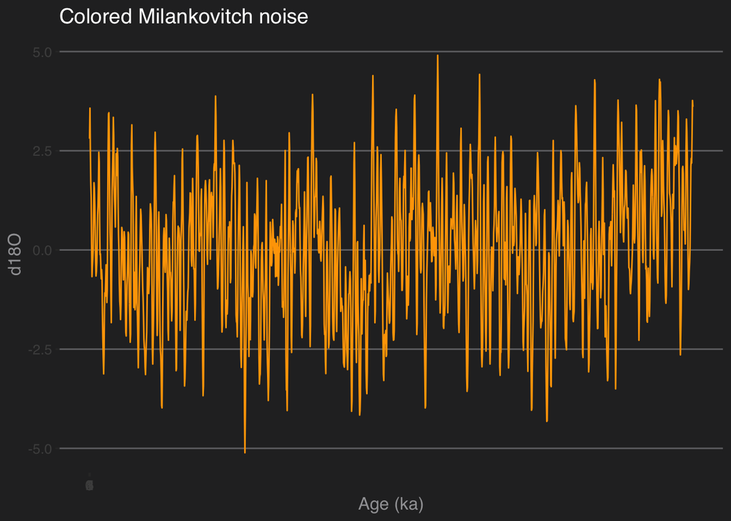

```r
library(ggplot2)
library(ggthemes)
#library(nuspectral)
library(astrochron)
library(scales)
library(reshape2) # for melt

dt = 2
time = seq(dt,3000,by=dt)
nt = as.numeric(length(time))
nf = nt
y = matrix(nrow = nt, ncol = nf)
alpha = 1 # noise color
fs = 1/dt
f0 = fs/nt
theta = 2*pi*runif(nf) # random phases

for(k in 1:nf){
  y[,k] = (f0*k)^(-alpha/2)*sin(2*k*f0*time + theta[k])
}
ys = scale(rowSums(y))  # add up and scale
# add Milankovitch harmonics
periods = c(100,41,23,19)
amp = 1
np = length(periods)
yp = y = matrix(nrow = nt, ncol = np)
for(i in 1:np){
  yp[,i] = amp*sin(2*pi/periods[i]*time)
}

yp = rowSums(yp)  # add up
yt = ys + yp

# plot
ggplot() + geom_line(aes(x=time,y=yt),colour="orange") + ggtitle("Colored Milankovitch noise") + ylab("d18O") + scale_x_continuous(breaks=seq(0,5)) + xlab("Age (ka)") + theme_hc(base_size = 12, base_family = "sans", style = "darkunica", bgcolor = NULL)
```

Now let’s use the nuspectral, wavelet-based method to estimate the spectrum. To save time, we load a pre-computed version, but the first two lines show how one would evaluate this spectrum using the nuspectral package.

```r
#tau = seq(min(time),max(time),length = max(nt %/% 2,5))
#spec.wwz = nuspectral:::nuwavelet_psd(time,yt,sigma=0.01,taus = tau)
load('spec.wwz.Rdata')   # load this to speed things up; TOGGLE for real example
period_range =  c(10, 1000)  # define range for estimation of spectral exponent
freq = spec.wwz$Frequency
pwr = spec.wwz$Power
f.low = 1/period_range[2]
f.high = 1/period_range[1]
freq_range = (freq>= f.low & freq<=f.high)
df.wwz = data.frame(cbind(freq, pwr))


# plotting parameters
m <- floor(log10(min(pwr[freq_range])))
M <- ceiling(log10(max(pwr[freq_range])))
period_ticks= c(10, 20, 50, 100, 200, 500, 1000)
```

You may want to fiddle with *tau*. Making this vector sparser will speed things up, though high-frequency variability will be undersampled. It thus requires some careful consideration. Here we choose to skip every other point, as a 4ka interval stil allows to resolve Milankovitch frequencies while not wasting time on high-frequency features, which are pure noise in this demo. Now let us plot the spectrum and test the significance of peaks in a couple of ways. First, let’s define a couple of auxiliary functions for plotting.

```r
# Define auxiliary functions for plotting
reverselog10_trans <- function(){
  trans <- function(x) -log(x, 10)
  inv <- function(x) 10^(-x)
  return(scales::trans_new("reverselog10-", trans, inv,
            log_breaks(base = 10),
            domain = c(1e-100, Inf)))
}
plotSpectraAnnotate = function (p, periods = c(19,23,41,100)){
  #get the x- and y-axis ranges actually used in the graph
  ggp <- ggplot_build(p)
  ylims <- ggp$layout$panel_params[[1]]$y.range # this will break with multiplots...
  for(per in periods){
    p <- p + annotate("segment", x = per, xend = per, y = 10**(ylims[1]-1), yend = 10**ylims[2],
    colour = "red", alpha = 0.5)
    p <- p +  annotate("text", x = 1.03*per, y = 2*10**ylims[2], label = format(per,digits=2, nsmall=0), colour = "red")
  }
return(p)
}
```

Since the process was defined as fractal (1/f) noise + some harmonics, a natural choice for the detection of harmonics would be to test against a power-law spectrum; in general, the spectral exponent (here, alpha = 1) is not known, so one would have to estimate it from the data. For this, we can re-use Stephen Meyer’s excellent astrochron package.

```r
plaw.fit = astrochron::pwrLawFit(df.wwz, dof = 2, flow = f.low, fhigh = f.high, output = 1, genplot = F)
```

```
##
## ----- ESTIMATING Power Law (1/f) Fit -----
##  * Number of frequencies in spectrum: 751
##  * Minimum frequency: 0
##  * Maximum frequency: 0.25
##  * Frequency spacing: 0.0003333333
##  * Slope from log(power) vs. log(frequency) fit (m): -0.9088656
##  * Y-intercept from log(power) vs. log(frequency) fit (b): -1.157271
##  * beta = 0.9088656
##  * log(N) = -0.9065892
##  * estimated bias = -0.2506816
```

```r
pl.df <- data.frame(plaw.fit[,union(1,c(5:7))]) # extract confidence limits and pull into dataframe
# rename columns to be less silly
names(pl.df)[2] <- "90% CL"
names(pl.df)[3] <- "95% CL"
names(pl.df)[4] <- "99% CL"
pl.df = melt(pl.df,id = 1)  # reshape so plotting is easier
```

From the pwrLawFit output we see that it estimates a slope of $\beta = +0.9$ ($\alpha$, in our notation), fairly close to the theoretical slope.

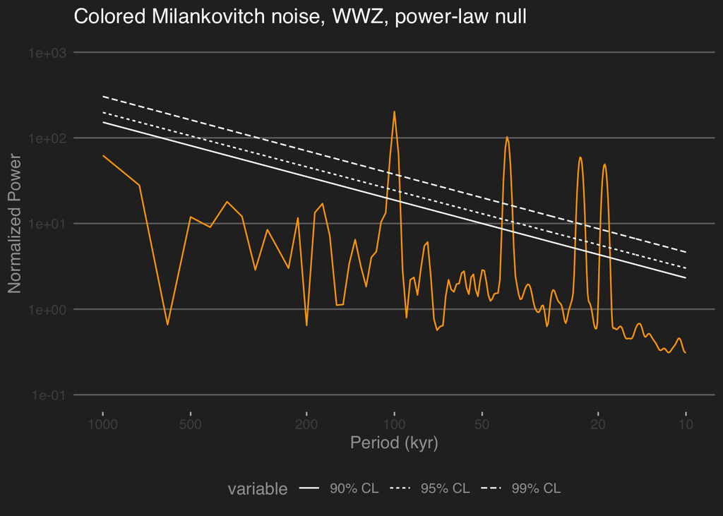

```r
# now plot it
p <- ggplot() + geom_line(aes(x=1/spec.wwz$Frequency,y=spec.wwz$Power),colour="orange") +
  theme_hc(base_size = 12, base_family = "sans", style = "darkunica", bgcolor = NULL) +
  theme(axis.ticks.x = element_line(color = "gray")) + scale_y_log10(limits = c(10^m,10^M)) +
  scale_x_continuous(breaks=period_ticks, minor_breaks = NULL, trans=reverselog10_trans(), limits = rev(period_range)) +
  xlab("Period (kyr)") + ylab("Normalized Power") + ggtitle("Colored Milankovitch noise, WWZ, power-law null") +
  geom_line(data=pl.df,aes(x=1/Frequency,y=value,linetype=variable),colour="white")

p <- plotSpectraAnnotate(p)
show(p)
```

We see four peaks at the frequencies where we put them (nothing short of reassuring). The peaks all breach the confidence limits, so the test works as it should.

Note that the default value of sigma (0.05) would give an overly smooth spectrum, which is why we picked sigma=0.01. You may want to try this with different values of sigma, optimizing the bias-variance tradeoff by hand. You will find that there is no free lunch.

Now, what if we had established significance against an AR(1) model, as is common in climate science? Here we re-use the work of [Meyers, (2012)](https://agupubs.onlinelibrary.wiley.com/doi/full/10.1029/2012PA002307), adapted from [astrochron::mtm()](https://rdrr.io/cran/astrochron/man/mtm.html)

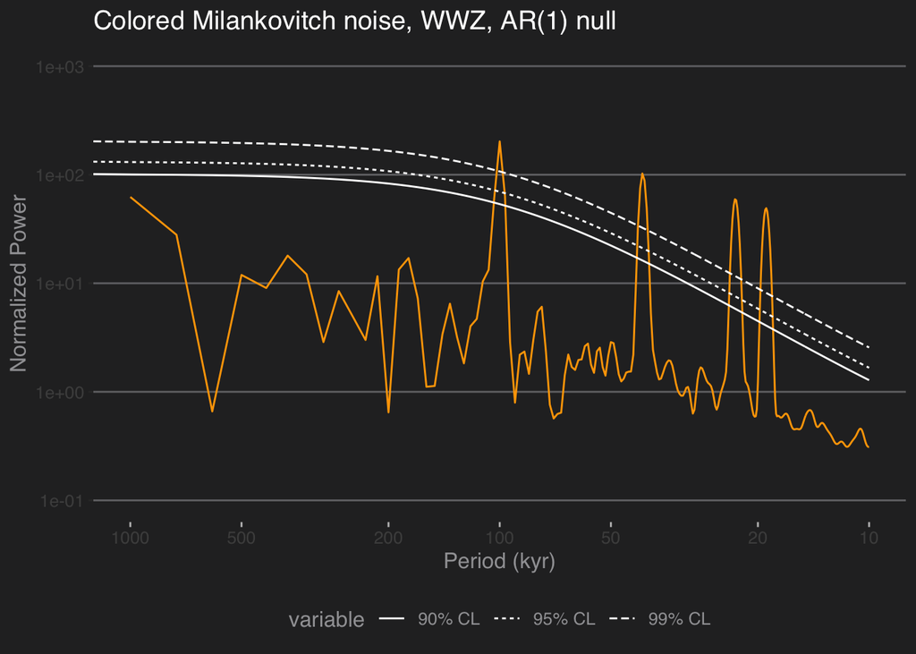

```r
ar.out <- ar(x = yt, aic = F, order.max = 1) # fit AR(1) model
rho = ar.out$ar  #extract lag-1 autocorrelation
So = mean(pwr)
Nyq <- 1/(2 * dt) # Nyquist frequency

RawAR = So * (1 - (rho^2))/(1 - (2 * rho * cos(pi * freq/Nyq)) + (rho^2)) # spectral density
dofAR =  2 # normally (2 * ntap) ... should be modified for WWZ where dof is function of frequency
chiRawAR <- (pwr/RawAR) * dofAR
chiCLRawAR <- pchisq(chiRawAR, df = dofAR)
AR1_90 <- RawAR * qchisq(0.9, df = dofAR)/dofAR
AR1_95 <- RawAR * qchisq(0.95, df = dofAR)/dofAR
AR1_99 <- RawAR * qchisq(0.99, df = dofAR)/dofAR

ar.df = data.frame(cbind(freq,AR1_90,AR1_95,AR1_99))    # bundle into a dataframe
# rename columns to be less silly
names(ar.df)[2] <- "90% CL"
names(ar.df)[3] <- "95% CL"
names(ar.df)[4] <- "99% CL"
ar.df = melt(ar.df,id = 1)  # reshape so plotting is easier
#
p <- ggplot() + geom_line(aes(x=1/freq,y=pwr),colour="orange") +
  theme_hc(base_size = 12, base_family = "sans", style = "darkunica", bgcolor = NULL) +
  theme(axis.ticks.x = element_line(color = "gray")) + scale_y_log10(limits = c(10^m,10^M)) +
  scale_x_continuous(breaks=period_ticks, minor_breaks = NULL, trans=reverselog10_trans(), limits = rev(period_range)) +
  xlab("Period (kyr)") + ylab("Normalized Power") + ggtitle("Colored Milankovitch noise, WWZ, AR(1) null") +
  geom_line(data=ar.df,aes(x=1/freq,y=value,linetype=variable),colour="white")

p <- plotSpectraAnnotate(p)
show(p)
```

All peaks still breach the confidence limits, though you can see that the peak at 100 kyr is barely doing so. Why?

That is because the spectrum of the AR(1) model is scaled to the mean spectral power (So), which in our case is dominated by the very lowest frequencies. This unduly “upped the ante” for this significance test.

Two points of note:

1. One often hears that a power-law test is more stringent at low-frequencies, we see that it was not the case here, because of the So scaling.
2. We see, once again, the critical importance of coming up with an appropriate null for every problem. There is no foolproof general recipe to detect “significant” peaks. There is no choice but to be very careful about how one defines the null hypothesis, often motivated by physical considerations.